# Assignment 6

2022-07-24

`Didn't update name`

```r
# Add any packages you want in this chunk:
library(car)
library(gvlma)
```

We are going to look at the property prices for Orange County. From there we are going to try and predict the sales price by linear regression.

# 1 Importing Data

Bring in the data and make sure the data types are correct. If not, make the proper changes. The file is located within this project. *data/prop_prices_reduced.csv*

```r
housing <- read.csv("data/prop_prices_reduced.csv")
housing$pool <- factor(housing$pool)
```

# 2 Plotting

Plot histograms for all variables. Additionally, add scatterplots for the relationships between all quantitative variables.

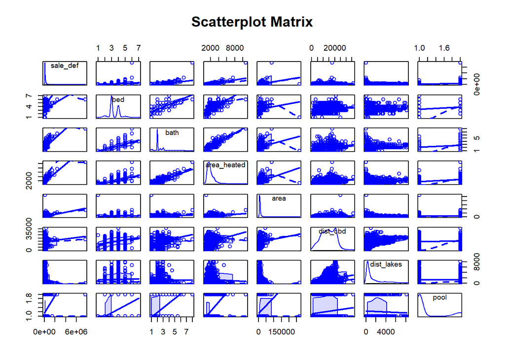

```r
# hist(housing$sale_def)
# hist(housing$bed)
# hist(housing$bath)
# hist(housing$area_heated)
# hist(housing$area)
# hist(housing$dist_cbd)
# hist(housing$dist_lakes)
# hist(housing$pool)
# cannot run histogram for categorical data code failed at this point

# plot(housing$sale_def, housing$area_heated)
# plot(housing$sale_def, housing$bed)
# plot(housing$sale_def, housing$bath)
# plot(housing$sale_def, housing$area)
# plot(housing$sale_def, housing$dist_cbd)
# plot(housing$sale_def, housing$dist_lakes)
# plot(housing$sale_def, housing$pool)


# This is sufficient
scatterplotMatrix(housing, spread = FALSE, lty.smooth = 2,
    main = "Scatterplot Matrix")
```

# 3 Summary Statistics

Provide basic summary statistics for univariate analysis. Also, provide the correlation between all the quantitative variables.

```r
summary(housing)
```

```
##     sale_def            bed             bath        area_heated
##  Min.   :  15296   Min.   :1.000   Min.   :1.000   Min.   :  650
##  1st Qu.: 115565   1st Qu.:3.000   1st Qu.:2.000   1st Qu.: 1387
##  Median : 151085   Median :3.000   Median :2.000   Median : 1744
##  Mean   : 200319   Mean   :3.398   Mean   :2.248   Mean   : 1955
##  3rd Qu.: 213902   3rd Qu.:4.000   3rd Qu.:2.500   3rd Qu.: 2301
##  Max.   :7629992   Max.   :7.000   Max.   :8.000   Max.   :10796
##       area           dist_cbd         dist_lakes      pool
##  Min.   :  1307   Min.   :  598.2   Min.   :  16.74   0:771
##  1st Qu.:  6498   1st Qu.: 9701.7   1st Qu.: 314.86   1:229
##  Median :  8733   Median :14552.0   Median : 638.82
##  Mean   : 10565   Mean   :14382.9   Mean   :1403.54
##  3rd Qu.: 11250   3rd Qu.:19369.2   3rd Qu.:1735.35
##  Max.   :269496   Max.   :36107.6   Max.   :8206.79
```

```r
# What about spread? sd/variance (-5)

# cor(housing)
# code fails because you cannot run a correlation on a factor. Pool needs
# to be removed for this to run. (-5)
```

# 4 Regression Analysis

Run a regression with all the variables included. Print results of the regression.

```r
Reg <- lm(sale_def ~ bed + bath + area_heated + area + dist_cbd + dist_lakes + pool, data = housing)
summary(Reg)
```

```
##
## Call:
## lm(formula = sale_def ~ bed + bath + area_heated + area + dist_cbd +
##     dist_lakes + pool, data = housing)
##
## Residuals:
##     Min      1Q  Median      3Q     Max
## -765238  -55999    9774   63848 4954827
##
## Coefficients:
##               Estimate Std. Error t value Pr(>|t|)
## (Intercept) -5.890e+04  3.093e+04  -1.904 0.057170 .
## bed         -8.492e+04  1.087e+04  -7.810 1.45e-14 ***
## bath         5.449e+04  1.507e+04   3.616 0.000315 ***
## area_heated  2.439e+02  1.430e+01  17.054  < 2e-16 ***
## area         3.548e+00  5.958e-01   5.955 3.61e-09 ***
## dist_cbd    -5.848e+00  1.090e+00  -5.366 1.00e-07 ***
## dist_lakes   9.651e-01  3.810e+00   0.253 0.800091
## pool1       -2.776e+04  1.640e+04  -1.693 0.090787 .
## ---
## Signif. codes:  0 '***' 0.001 '**' 0.01 '*' 0.05 '.' 0.1 ' ' 1
##
## Residual standard error: 194900 on 992 degrees of freedom
## Multiple R-squared:  0.547,  Adjusted R-squared:  0.5438
## F-statistic: 171.2 on 7 and 992 DF,  p-value: < 2.2e-16
```

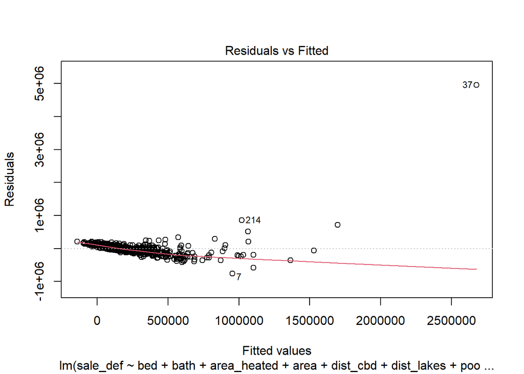

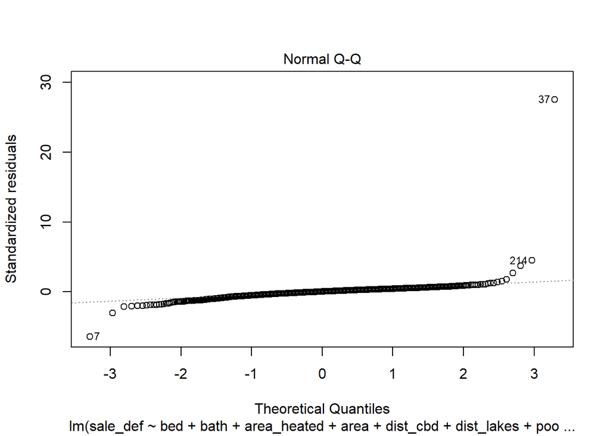

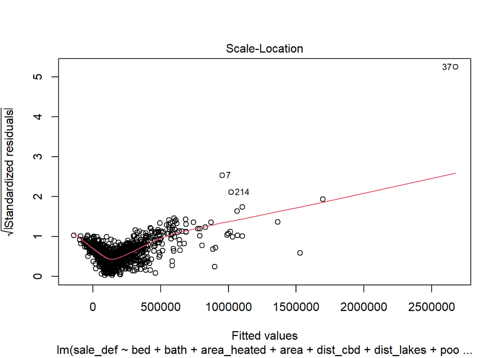

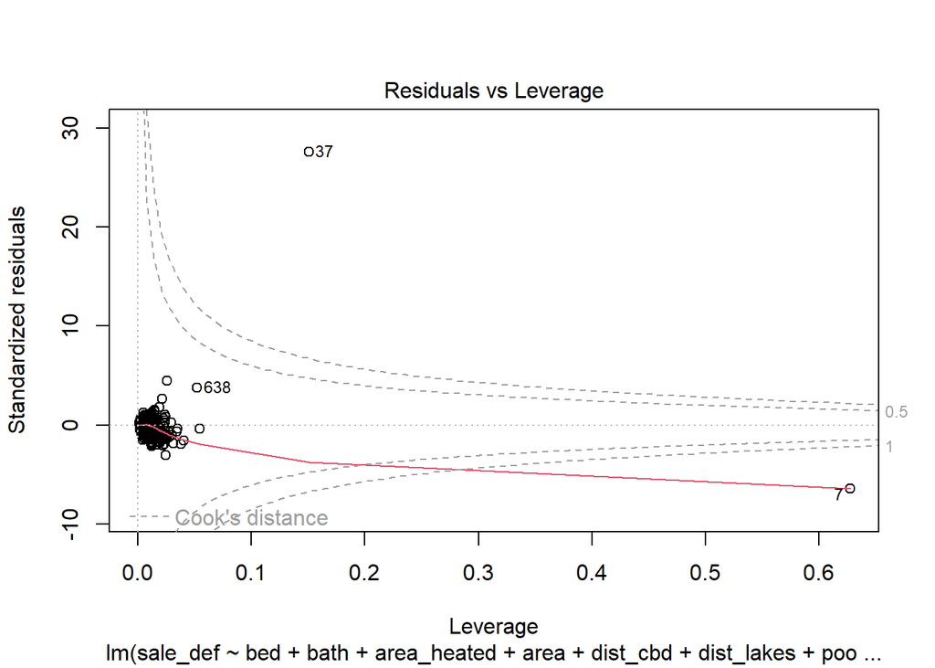

```r
plot(Reg)
```

```r
durbinWatsonTest(Reg)
```

```
##  lag Autocorrelation D-W Statistic p-value
##    1    -0.008920317      2.017485   0.724
##  Alternative hypothesis: rho != 0
```

```r
#gvmodel <- gvlma(Test_1)
#summary(gvmodel)
# Code failed to run at this level because Test_1 doesn't exist until later
# chunk (-2)

gvlma(Reg)
```

```
##
## Call:
## lm(formula = sale_def ~ bed + bath + area_heated + area + dist_cbd +
##     dist_lakes + pool, data = housing)
##
## Coefficients:
## (Intercept)          bed         bath  area_heated         area     dist_cbd
##  -5.890e+04   -8.492e+04    5.449e+04    2.439e+02    3.548e+00   -5.848e+00
##  dist_lakes        pool1
##   9.651e-01   -2.776e+04
##
##
## ASSESSMENT OF THE LINEAR MODEL ASSUMPTIONS
## USING THE GLOBAL TEST ON 4 DEGREES-OF-FREEDOM:
## Level of Significance =  0.05
##
## Call:
##  gvlma(x = Reg)
##
##                        Value p-value                   Decision
## Global Stat        7497980.4       0 Assumptions NOT satisfied!
## Skewness             45659.6       0 Assumptions NOT satisfied!
## Kurtosis           7450926.5       0 Assumptions NOT satisfied!
## Link Function          782.2       0 Assumptions NOT satisfied!
## Heteroscedasticity     612.1       0 Assumptions NOT satisfied!
```

Which of the variables tested significant at the 95% level? Looking at the results and answering outside of the chunk is sufficient.

`only independent variables can test significant` `pool was not significant at 95% level`

## 4.1 Evaluating the model

As is, are any of the Gauss-Markov assumptions violated? If so, which ones? How can you fix the issues?

`Assumption one` is violated as many of the relationships between the variables are non-linear. For example, the relationship between sale_def and pools does not represent a linear relationship as the points plotted are 2 separate lines.

`The one you describes related to assumption 3, not assumption 1` `What about the rest of the assumptions?`

## 4.2 New Model

Based off of your findings in the previous section, make changes to the variables, the functional form, etc.

```r
housing$log_price <- (housing$sale_def/housing$area)
housing$log_lake <- (housing$dist_lakes^2)
housing$log_bath <- log(housing$bath)

Reg <- lm(log_price ~ bed + bath + area_heated + area + dist_cbd + dist_lakes + pool, data = housing)
summary(Reg)
```

```
##
## Call:
## lm(formula = log_price ~ bed + bath + area_heated + area + dist_cbd +
##     dist_lakes + pool, data = housing)
##
## Residuals:
##     Min      1Q  Median      3Q     Max
## -22.792  -6.066  -1.767   3.711  78.043
##
## Coefficients:
##               Estimate Std. Error t value Pr(>|t|)
## (Intercept)  1.147e+01  1.566e+00   7.324 4.98e-13 ***
## bed         -3.616e+00  5.506e-01  -6.568 8.20e-11 ***
## bath         6.909e+00  7.631e-01   9.054  < 2e-16 ***
## area_heated  4.854e-03  7.241e-04   6.703 3.41e-11 ***
## area        -3.617e-04  3.017e-05 -11.991  < 2e-16 ***
## dist_cbd     2.727e-05  5.518e-05   0.494   0.6213
## dist_lakes   4.347e-04  1.929e-04   2.253   0.0245 *
## pool1       -5.165e-01  8.302e-01  -0.622   0.5340
## ---
## Signif. codes:  0 '***' 0.001 '**' 0.01 '*' 0.05 '.' 0.1 ' ' 1
##
## Residual standard error: 9.868 on 992 degrees of freedom
## Multiple R-squared:  0.3661, Adjusted R-squared:  0.3616
## F-statistic: 81.84 on 7 and 992 DF,  p-value: < 2.2e-16
```

```r
Test_1 <- lm(sale_def ~ area_heated + bath + area + bed + dist_cbd + dist_lakes, data = housing)
summary(Test_1)
```

```
##
## Call:
## lm(formula = sale_def ~ area_heated + bath + area + bed + dist_cbd +
##     dist_lakes, data = housing)
##
## Residuals:
##     Min      1Q  Median      3Q     Max
## -746514  -56236    7638   64493 4986240
##
## Coefficients:
##               Estimate Std. Error t value Pr(>|t|)
## (Intercept) -5.150e+04  3.065e+04  -1.681 0.093168 .
## area_heated  2.395e+02  1.408e+01  17.015  < 2e-16 ***
## bath         5.335e+04  1.507e+04   3.540 0.000418 ***
## area         3.473e+00  5.947e-01   5.840 7.05e-09 ***
## bed         -8.547e+04  1.088e+04  -7.857 1.02e-14 ***
## dist_cbd    -5.854e+00  1.091e+00  -5.366 1.00e-07 ***
## dist_lakes   1.095e+00  3.813e+00   0.287 0.774087
## ---
## Signif. codes:  0 '***' 0.001 '**' 0.01 '*' 0.05 '.' 0.1 ' ' 1
##
## Residual standard error: 195100 on 993 degrees of freedom
## Multiple R-squared:  0.5457, Adjusted R-squared:  0.543
## F-statistic: 198.8 on 6 and 993 DF,  p-value: < 2.2e-16
```

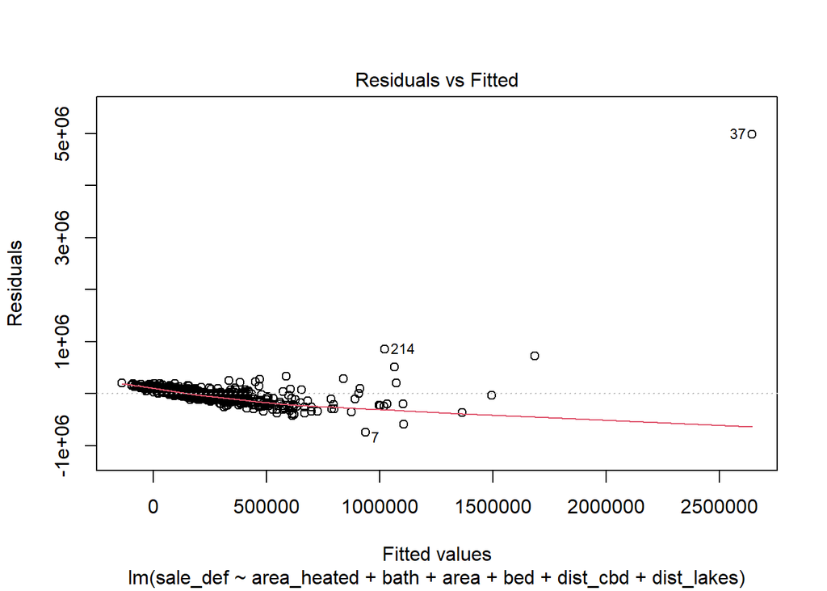

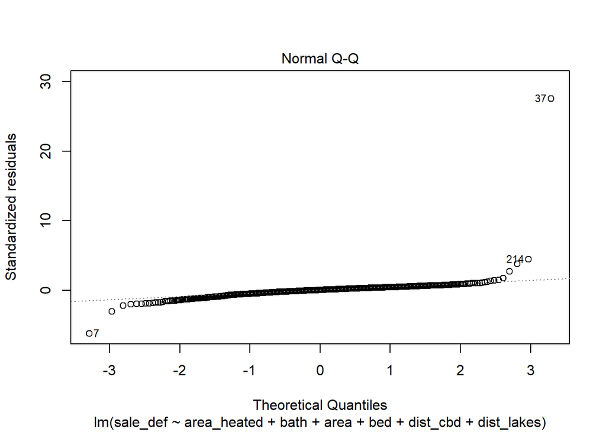

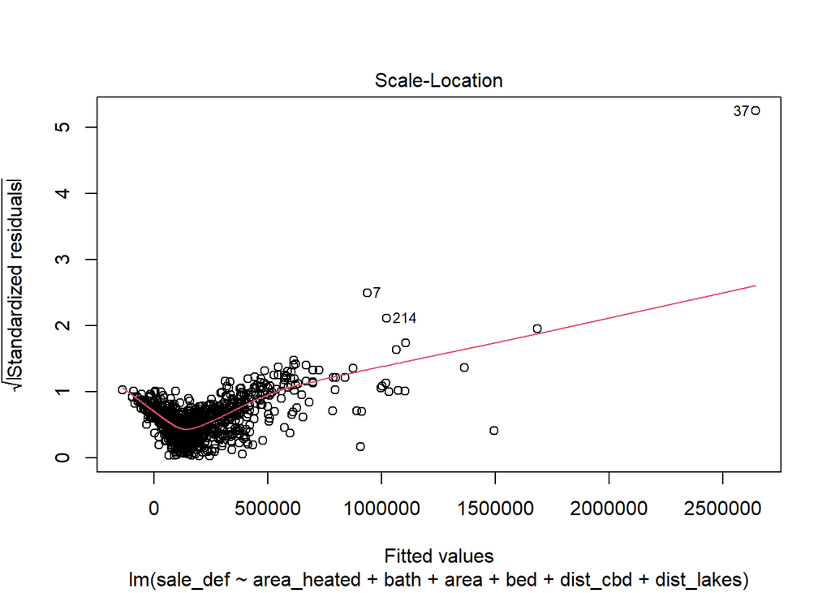

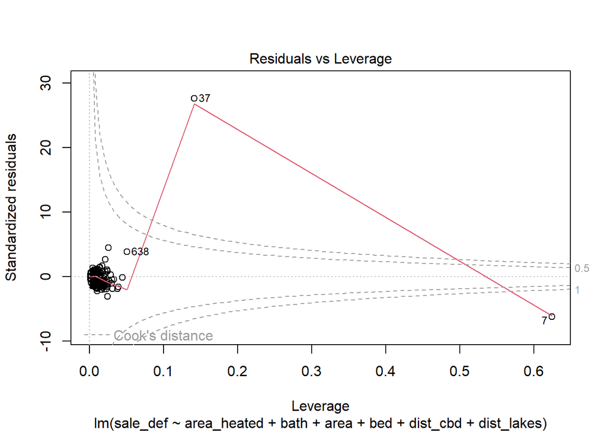

```r
plot(Test_1)
```

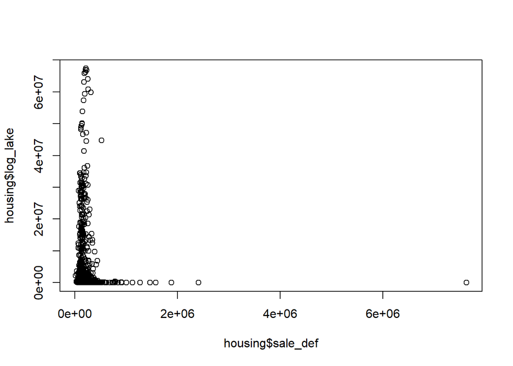

```r
plot(housing$sale_def, housing$log_lake)
```

```r
# Which model did you choose?
# After your changes were the Gauss-Markov assumptions valid?
# Assuming that the code in earlier chunk was meant for this:
gvmodel <- gvlma(Test_1)
summary(gvmodel)
```

```
##
## Call:
## lm(formula = sale_def ~ area_heated + bath + area + bed + dist_cbd +
##     dist_lakes, data = housing)
##
## Residuals:
##     Min      1Q  Median      3Q     Max
## -746514  -56236    7638   64493 4986240
##
## Coefficients:
##               Estimate Std. Error t value Pr(>|t|)
## (Intercept) -5.150e+04  3.065e+04  -1.681 0.093168 .
## area_heated  2.395e+02  1.408e+01  17.015  < 2e-16 ***
## bath         5.335e+04  1.507e+04   3.540 0.000418 ***
## area         3.473e+00  5.947e-01   5.840 7.05e-09 ***
## bed         -8.547e+04  1.088e+04  -7.857 1.02e-14 ***
## dist_cbd    -5.854e+00  1.091e+00  -5.366 1.00e-07 ***
## dist_lakes   1.095e+00  3.813e+00   0.287 0.774087
## ---
## Signif. codes:  0 '***' 0.001 '**' 0.01 '*' 0.05 '.' 0.1 ' ' 1
##
## Residual standard error: 195100 on 993 degrees of freedom
## Multiple R-squared:  0.5457, Adjusted R-squared:  0.543
## F-statistic: 198.8 on 6 and 993 DF,  p-value: < 2.2e-16
##
##
## ASSESSMENT OF THE LINEAR MODEL ASSUMPTIONS
## USING THE GLOBAL TEST ON 4 DEGREES-OF-FREEDOM:
## Level of Significance =  0.05
##
## Call:
##  gvlma(x = Test_1)
##
##                        Value p-value                   Decision
## Global Stat        7796032.0       0 Assumptions NOT satisfied!
## Skewness             47068.2       0 Assumptions NOT satisfied!
## Kurtosis           7747563.8       0 Assumptions NOT satisfied!
## Link Function          778.6       0 Assumptions NOT satisfied!
## Heteroscedasticity     621.5       0 Assumptions NOT satisfied!
```

# 5 Prediction

- 2 bed
- 2 bath
- area_heated = 1223
- area = 9750
- dist_cbd = 19368
- dist_lakes = 490
- no pool

```r
# incomplete
```

[output not shown]